# intro_map_reduce slides

#### The Need for MapReduce

- CPUs execute operations on data loaded into RAM
- Large datasets must be read from disk into RAM
- Issues arise when data cannot fit into RAM
- CPU cost is often discussed, but I/O cost is generally overlooked
- Reading large files is I/O-bound, not necessarily CPU-bound
- Disk I/O speed limits data processing

#### Disk Speed Benchmarking

- Open-source disk speed benchmarking with `fio`
  - [How Fast are Your Disks?](https://arstechnica.com/gadgets/2020/02/how-fast-are-your-disks-find-out-the-open-source-way-with-fio/) (2/6/2020)
  - FIO: Flexible I/O is a tool that helps you benchmark and verify disk I/O performance.
  - A really useful tool for data engineers

```
fio --name=test --ioengine=sync --rw=randwrite --bs=4k --numjobs=1 --size=100m --time_based --runtime=60s
```

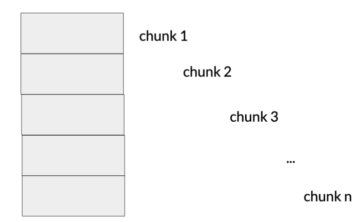

### Issue with Batching and I/O Costs

- While CPU costs are often a focal point in discussions about performance, the cost of I/O (Input/Output) is frequently overlooked.
- Even operations that are not CPU-intensive can become bottlenecks when dealing with large files due to the limitations of I/O speed.
- A standard 7200 RPM HDD typically offers a read/write speed ranging from 80 to 160 MB/s.
- Higher-end drives, like 15k RPM HDDs or SSDs, can offer significantly faster speeds, averaging around 350 MB/s.

Reading a very large file can be time-consuming.

- At a speed of 200 MB/s, it would take approximately 11 GB per minute or around 703 GB per hour to read a file.
  - For example, reading a 200 TB file would require more than 200 hours.
- Another challenge is memory constraints
  - Since it's often infeasible to store large files in RAM, each operation on the file necessitates reading the entire file from disk again.

#### Using GNU Parallel

- GNU Parallel allows concurrent execution of commands or shell scripts
  - Local and distributed execution via SSH
  - [GNU Parallel Tutorial](https://www.admin-magazine.com/HPC/Articles/GNU-Parallel-Multicore-at-the-Command-Line-with-GNU-Parallel)
  - [Parallel-SSH](https://www.tecmint.com/run-commands-on-multiple-linux-servers/)

#### GNU Parallel Example: Word Count

```
# Remove empty lines
awk NF t8.shakespeare.txt > text_no_empty_lines.txt
# Split into chunks
split -l 500 text_no_empty_lines.txt text_subset_
# Process chunks using Parallel
ls text_subset* | grep -v map | parallel "awk 'BEGIN {RS=\"[[:punct:][:space:]]+\"} {print \$0}' {} > {}.map"
ls *.map | parallel "sort {} | uniq -c > {}.counts"
```

- Combining all the counts can be then achived using:

```
cat *.counts | sort -k2,2 | awk '{counts[$2]+=$1} END {for (word in counts) print counts[word], word}' | sort -k1,1nr -k2,2
```

### Parallel and SSH

- Parallel gas the capability to distribute tasks across multiple machines using SSH

```
ls text_subset* | parallel --sshloginfile sshnodes \
     --dry-run \
     --transfer \
     --return {}.map \
     --cleanup \
      "<command>"
```

- Need to handle file transer, program installtion on remote machines, etc.

### Challenges in the Current Approach

- Complexity of Distributed Programming
  - Even for straightforward examples like the one discussed, there are multiple steps involved: splitting the data, transferring it, and finally merging the results.
- Lack of Redundancy
  - With a server failure rate of once every 3 years, a system with 1000 servers would experience approximately one failure per day.
    - For context, Google manages an estimated 2.5 million machines. [Source](https://www.datacenterknowledge.com/archives/2017/03/16/google-data-center-faq)
- Data Transfer Overheads
  - Shuttling data back and forth adds significant computational costs.

### What is an HPC Cluster

- High-Performance Computing (HPC)aggregating computing power to solve complex problems in science, engineering, or other fields
  - HPC systems often consist of clusters of computers that work in parallel to perform tasks more quickly and efficiently than using a single machine.
- Example of a cluster topology [Apollo2](https://docs.hpc.sussex.ac.uk/apollo2/)

[figure not shown]

#### The HPC Approach

- Distribute file chunks across multiple machines.
- Each machine processes its chunk independently.
- Effective for batch-like operations.
- Pros:
  - This approch is often called embarrassingly or delightfully or pleasingly parallel.
  - Requires little effort to parallelize.
- Cons:
  - Distributed programs are complex to manage.
    - E.g.: how do we split data, how do transer it, how do we know it completed successfully, what happens if a server dies?
  - Lack of redundancy and fault tolerance.

#### MapReduce to the Rescue

- Framework on top of HPC clusters
- Addresses fault tolerance, data redundancy
- Map Reduce Components
  - Distributed File System
    - Data chunks replicated across nodes
    - Metadata managed by master nodes
  - Mapping and Reducing
    - Mapping: Assign initial values to keys
    - Reducing: Aggregate initial values

#### Open-Source MapReduce Implementations

- Hadoop
  - Implemented in Java
  - Hadoop Distributed File System (HDFS)
- High-Level Abstractions
  - Hive: SQL-like language
  - Pig: Pig-Latin scripting language

### What a MapReduce Framework Needs to Provide:

- Data Partitioning: Keeping track of data chunks and their locations on different machines.
- Task Scheduling: Distributing program execution across available nodes.
- Node Availability: If there are more chunks than nodes, monitor when a node finishes its task to assign a new chunk.
- Result Management: Observing execution to process the results.
- Inter-Machine Communication: Managing necessary data exchange between machines.
- Failure Recovery: Handling node failures by reassigning their tasks to other available machines.
- Developer-Friendly: The framework requires developers to write only the map and reduce functions.
  - Provide implementation of common operations
  - E.g., what happens during a `group by`?

```python
# On Linux
# !head -c 1G </dev/urandom > /tmp/myfile
# BE EXTRA CARFUL WITH THE FOLLOWIN
!dd if=/dev/zero of=/tmp/temp_10GB_file bs=1024 count=10485760
```

```
10485760+0 records in
10485760+0 records out
10737418240 bytes transferred in 25.492404 secs (421200693 bytes/sec)
```

```python
!du -sch /tmp/temp_10GB_file
```

[output not shown]

```python
%%timeit
# Running on a solid state drive.
for _ in open("/tmp/temp_10GB_file", "rb").readlines():
  pass
```

```
9.08 s ± 118 ms per loop (mean ± std. dev. of 7 runs, 1 loop each)
```

### Map Reduce -- Distributed file system

- Chunks are (16-64 MB) replicated across chunk servers (compute nodes)
  - Typically 3 replicates per chunk
  - No two chunks are on the same machine
  - preferably across node racks
- Catalogue of where each chunk is stored on a master nodes

### MapReduce for Word Counting - Continued

- Use Case: Counting words in a large document
  - Analogous to the task of reading K-mers in a DNA sequence
- Memory Constraints: Word counts exceed available RAM, requiring multiple machines.
- Chunk Management: The main cluster node keeps track of the location of each data chunk.
- Mapping Step: Individual nodes perform the 'mapping' of words to initial counts.
- Reducing Step: Specific nodes take on the task of 'reducing' initial counts to final totals.

[figure not shown]

### Map Reduce Diagram

[figure not shown]

### Roles of the Map-Reduce Framework

- Data Partitioning: Divides the data into chunks and keeps track of their locations.
- Task Scheduling: Coordinates the program's execution across multiple nodes.
- Execution Monitoring: Oversees the runtime progress of tasks.
- Grouping by Keys: Organizes data based on specified keys during the reduce phase.
- Intermachine Communication: Manages data and control flow between nodes.
- Fault Handling: Addresses node failures and reallocates tasks as needed.

### Role of Master Node

- Keeps track of the status of the task
  - idle, in progress, or completed
- Idle tasks are scheduled as workers become available
- When a map task completes it sends the master the location of its R intermediate files
  - Each of the R intermediate files is associated with the reducer task
  - The master pushes info to reducers
  - Reduced do not start computaiton (or file copies) until all map tasks are completed
- Master pings workers to detect compute node failures
  - Resets to idle all map tasks that ran on that compute node
  - Resets to idle in progress reduce tasks on the compute node

### Map Reduce Refinements - 1

- Save on the network overhead by running intermediate combine operations on each machine
  - In many instances, combiner can be a reducer operations
    - Reduce operation is commutative and associative

[figure not shown]

### Map-Reduce Techniques for Non-Standard Operations

- Some operations can't be easily reduced to a single value using the basic Map-Reduce approach.
  - For instance, calculating the average or median is more complex than simply summing numbers.

```
>> np.mean([1,1,1,1,1,1,1,1,8])
    1.777
    >> np.mean([np.mean([1,1,1,1,1]), np.mean([1,1,1,8])])
    1.875
```

### Map-Reduce Techniques for Non-Standard Operations

- Trick for Calculating Averages:
  - The combiner generates a key-value pair `<k1, (sum_k1_i, count_k1_i)>` for each compute node `i`.
  - Here, `sum_k1_i` is the sum of the values and `count_k1_i` is the number of values.
- The reducer then computes the true average as follows:

```
<k1, (sum_k1_1 + sum_k1_2 + ... + sum_k1_i) / (count_k1_1 + count_k1_2 + ... + count_k1_i)>
```

### Map-Reduce Techniques for Non-Standard Operations

- How can we use map reduce to compute the median?

### Open Source Map-Reduce Implementations

- Hadoop:
  - Open source implementation in Java
  - Uses the Hadoop Distributed File System (HDFS)
  - Files are stored as AVRO files
    - Row-based format makes it easy to chunk the files
  - Available on most cloud services platforms
    - [Amazon Elastic Map Reduce (EMR) services](https://aws.amazon.com/emr/features/hadoop/)
    - Google [Dataproc](https://cloud.google.com/dataproc), the managed Spark and Hadoop service
    - Microsoft Azure [HDInsight](https://azure.microsoft.com/en-us/services/hdinsight/)

### Open Source Map-Reduce Implementations

- Hive and Pig
  - Apache SQL-Like abstraction on top of map-reduce
    - Very common use cases of Hadoop
    - No need to implement `select`, `join`, `filter`, `agg` like operations.
  - Pig uses its own language (pig-Latin) for writing scripts
  - Hive uses SQL-like language for interactive queries or report generation
  - Hive and Pig are also available through cloud services providers
- Note that cloud providers have a computation (CPU time) cost, disk storage cost, and file transfer cost.

### Example Comparing Genomes

- Total of 5000 genomes
- Each genome is stored in its own file (~ 1MB per file) genome_id (g1, g2, ..., g5000), genome_sequence(s1, s2, ..., s5000)
  - File are relicated for redundancy
- We would like to compute all pairwise comparison using Hadoop

### Example Comparing Genomes - Solution 1

1. map oprations
- map 1

`<key=(gi, gj) value= si >` where $i \ne j$ and therefore `<key=(gj, gi) value= sj>`

- Hadoop takes care of running the mapper where the data is located.
2. combine (automatic; does not need to be manually implemented )

`<key=(gi, gj), value= [si, sj]>`

3. reduce by comparing [si, sj]
- What is the problem with such an implementation?

### Example Comparing Genomes - Solution 1 and Data Transfer

- There are 5000 genomes
- Each genome is compared against 4999 genomes to reduce to a unique comparison
- In the worst-case scenario, 24,995,000 of ~1 MB files
  - 23TB of data is transferred
  - Requires ~6 Hours on 10GB connect
  - Requires 2 days and 8 hours on 1GB Connect

### Example Comparing Genomes - Solution 2

- Split data by group of 100 genomes instead
- Each genome is in one and only one group i (ri) of the 50 resulting groups
- Map operation: for each genome, produce 49 pairs
  - <key=(ri, rj) value= gi> where gi in ri
  - <key=(ri, rj) value= gj> where gj in rj
  - Since each group contains 100 genomes, the list will consist of 200 genomes
- group by: group all all elements that have the same key
- Reduce operation: compute all pairs within a list

### Example

```
r1 = 1, 2, 3
g2 = 4, 5, 6
g3 = 7, 8, 9
```

##### map

```
<k(g1, g2), v = 1>, <k(g1, g3), v = 1>, <k(g1, g2), v = 2>,
<k(g1, g3), v = 2>, <k(g1, g2), v = 3>, <k(g1, g3), v = 3>,
<k(g1, g2), v = 4>, <k(g2, g3), v = 4>, <k(g1, g2), v = 5>,
<k(g2, g3), v = 5>, <k(g1, g2), v = 6>, <k(g2, g3), v = 6>,
<k(g1, g3), v = 7>, <k(g2, g3), v = 7>, <k(g1, g3), v = 8>,
<k(g2, g3), v = 8>, <k(g1, g3), v = 9>, <k(g2, g3), v = 9>
```

##### Combine

```
<k(g1, g2), val=[1,2,3,4,5,6]>
<k(g1, g3), val=[1,2,3,7,8,9]>
<k(g2, g3), val=[4,5,6,7,8,9]>
```

### Example Comparing Genomes - Refinement

- Previous reduce operations computed the same pairs across multiple reducers.
- We can constrain conditions where each is computed.
  - if i == j+1, compute pairs between elements in the first half of the list
  - if j is max group size, compute pairs between elements of the second half of the list.